# Practical Machine Learning - Course Project

Anastasios Vlaikidis

3/7/2021

## Import and prepare the Data

```r
# Workspace clean up
rm(list = ls())
```

```r
DataT <- read.csv("pml-training.csv")
DataTesting <-read.csv("pml-testing.csv")
```

We see that we have some strange strings and we will replace them with NA.

```r
# Replace with NA
DataT <- read.csv("pml-training.csv",na.strings =c("#DIV/0!","NA",""))
DataTesting <- read.csv("pml-testing.csv",na.strings =c("#DIV/0!","NA",""))
```

Removing NA.

```r
#Remove columns with more than 95% of NA or "" values
limit<- dim(DataT)[1] * .95
gCols <-!apply(DataT, 2,
          function(x) sum(is.na(x)) > limit||sum(x=="")> limit)
DataT <- DataT[,gCols]

 limit2 <-dim(DataTesting)[1]*.95
 gCols2 <-!apply(DataTesting, 2,
           function(x) sum(is.na(x)) > limit2||sum(x=="")> limit2)
DataTesting<-DataTesting[,gCols2]
```

Dropping unwanted columns.

```r
suppressMessages(library(dplyr))
DataT<-dplyr::select(DataT,-c(1,2,5))
DataTesting<-dplyr::select(DataTesting,-c(1,2,5))
```

We will also remove the variables from our training dataset with near-zero variance.

```r
suppressMessages(library(caret))
bCols<- nearZeroVar(DataT,saveMetrics = T)
DataT <- DataT[,bCols$nzv==F]
DataTesting <- DataTesting[,-3]
```

Our target variable is called “classe” and its in the last column of our dataset DataT.It is a character variable.We will make it factor so we can easily see its levels.

```r
class(DataT$classe)
```

```
## [1] "character"
```

```r
DataT[,length(DataT)] <-as.factor(DataT$classe)
class(DataT$classe)
```

```
## [1] "factor"
```

```r
levels(DataT$classe)
```

```
## [1] "A" "B" "C" "D" "E"
```

It has five levels: A,B,C,D,E. Since our target variable qualitative, it will be sensible to draw a barplot and a frequency table to represent our findings..

```
##
##    Cell Contents
## |-------------------------|
## |                   Count |
## |             Row Percent |
## |-------------------------|
##
## Total Observations in Table:  19622
##
##           |        A  |        B  |        C  |        D  |        E  |
##           |-----------|-----------|-----------|-----------|-----------|
##           |     5580  |     3797  |     3422  |     3216  |     3607  |
##           |    28.44% |    19.35% |    17.44% |    16.39% |    18.38% |
##           |-----------|-----------|-----------|-----------|-----------|
##
##
```

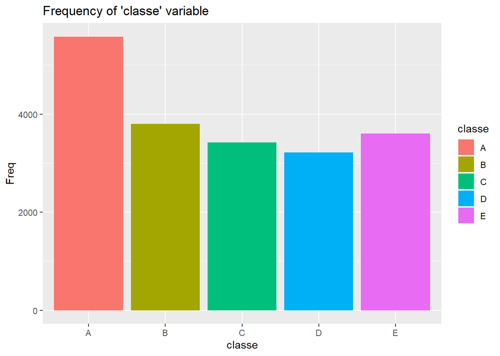

## Data spliting

```r
# we use 75% to train the model and 25% to test it
 inTrain<-createDataPartition(y=DataT$classe, p=.75, list = F)
 training<-DataT[inTrain,]  # training set
 testing<-DataT[-inTrain,]  # testing set
```

## Cross-Validation

```r
#for reproducibility
set.seed(22)
# 10-fold cross validation
ctrl<-trainControl(method="cv",number = 10)
```

## Fit a model

We choose Random Forest because it automatically selects important variables and is robust regarding correlated predictors and outliers in general.Tree models split numeric data into two groups by looking at conditional statistics of the target variable and will not benefit as much from exponential types of transformations(BoxCox, YeoJohnson, exponential).Monotone transformations(order unchanged) like log will produce the same splits.However, without proper cross-validation, the model can be over-fitted especially with large numbers of variables and results may differ from one run to the next.

```r
modelFit <-caret::train(classe~.,data=training,method="rf",
        trControl = ctrl, ntree=10)
modelFit
```

```
## Random Forest
##
## 14718 samples
##    55 predictor
##     5 classes: 'A', 'B', 'C', 'D', 'E'
##
## No pre-processing
## Resampling: Cross-Validated (10 fold)
## Summary of sample sizes: 13246, 13247, 13245, 13247, 13248, 13246, ...
## Resampling results across tuning parameters:
##
##   mtry  Accuracy   Kappa
##    2    0.9886535  0.9856468
##   28    0.9979622  0.9974225
##   55    0.9963986  0.9954445
##
## Accuracy was used to select the optimal model using the largest value.
## The final value used for the model was mtry = 28.
```

Model Predictions

```r
# our predicted values
predictions<-predict(modelFit, newdata=testing,type = "raw")
```

Confusion matrix and Statistics

```r
AC <-confusionMatrix(testing$classe,predictions)
AC
```

```
## Confusion Matrix and Statistics
##
##           Reference
## Prediction    A    B    C    D    E
##          A 1394    1    0    0    0
##          B    2  944    3    0    0
##          C    0    2  852    1    0
##          D    0    0    3  801    0
##          E    0    0    0    0  901
##
## Overall Statistics
##
##                Accuracy : 0.9976
##                  95% CI : (0.9957, 0.9987)
##     No Information Rate : 0.2847
##     P-Value [Acc > NIR] : < 2.2e-16
##
##                   Kappa : 0.9969
##
##  Mcnemar's Test P-Value : NA
##
## Statistics by Class:
##
##                      Class: A Class: B Class: C Class: D Class: E
## Sensitivity            0.9986   0.9968   0.9930   0.9988   1.0000
## Specificity            0.9997   0.9987   0.9993   0.9993   1.0000
## Pos Pred Value         0.9993   0.9947   0.9965   0.9963   1.0000
## Neg Pred Value         0.9994   0.9992   0.9985   0.9998   1.0000
## Prevalence             0.2847   0.1931   0.1750   0.1635   0.1837
## Detection Rate         0.2843   0.1925   0.1737   0.1633   0.1837
## Detection Prevalence   0.2845   0.1935   0.1743   0.1639   0.1837
## Balanced Accuracy      0.9991   0.9978   0.9961   0.9990   1.0000
```

Out of sample error

```r
t<-round(((1 - AC$overall[1])*100),2)
cat("out of sample error:",t,"%")
```

```
## out of sample error: 0.24 %
```

Variable importance

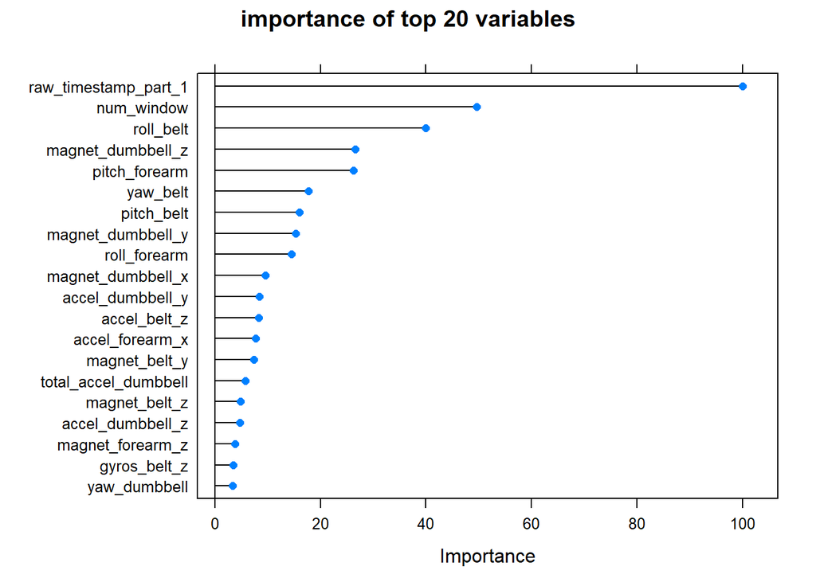

```r
var.imp<-varImp(modelFit)
#plot the top 20 importance variables
plot(var.imp,main="importance of top 20 variables",top = 20)
```

## Course Project Prediction Quiz Portion

```r
results <-predict(modelFit ,newdata = DataTesting,type = "raw")
results
```

```
##  [1] B A B A A E D B A A B C B A E E A B B B
## Levels: A B C D E
```